# Risk Factor Analysis

## Outcome Variable

**Outcome Variable:** ever_swasted

## Predictor Variables

**Intervention Variable:** mbmi

**Adjustment Set:**

- arm
- W_mage
- meducyrs
- feducyrs
- single
- brthmon
- delta_W_mage
- delta_meducyrs
- delta_feducyrs
- delta_single
- delta_brthmon

## Stratifying Variables

The analysis was stratified on these variable(s):

- agecat
- studyid
- country

## Data Summary

| agecat | studyid | country | mbmi | ever_swasted | n_cell | n |
| --- | --- | --- | --- | --- | --- | --- |
| 0-24 months | ki0047075b-MAL-ED | BANGLADESH | Normal weight | 0 | 209 | 254 |
| 0-24 months | ki0047075b-MAL-ED | BANGLADESH | Normal weight | 1 | 13 | 254 |
| 0-24 months | ki0047075b-MAL-ED | BANGLADESH | Underweight | 0 | 24 | 254 |
| 0-24 months | ki0047075b-MAL-ED | BANGLADESH | Underweight | 1 | 8 | 254 |
| 0-24 months | ki0047075b-MAL-ED | BRAZIL | Normal weight | 0 | 207 | 221 |
| 0-24 months | ki0047075b-MAL-ED | BRAZIL | Normal weight | 1 | 4 | 221 |
| 0-24 months | ki0047075b-MAL-ED | BRAZIL | Underweight | 0 | 10 | 221 |
| 0-24 months | ki0047075b-MAL-ED | BRAZIL | Underweight | 1 | 0 | 221 |
| 0-24 months | ki0047075b-MAL-ED | INDIA | Normal weight | 0 | 177 | 242 |
| 0-24 months | ki0047075b-MAL-ED | INDIA | Normal weight | 1 | 16 | 242 |
| 0-24 months | ki0047075b-MAL-ED | INDIA | Underweight | 0 | 41 | 242 |
| 0-24 months | ki0047075b-MAL-ED | INDIA | Underweight | 1 | 8 | 242 |
| 0-24 months | ki0047075b-MAL-ED | NEPAL | Normal weight | 0 | 229 | 238 |
| 0-24 months | ki0047075b-MAL-ED | NEPAL | Normal weight | 1 | 9 | 238 |
| 0-24 months | ki0047075b-MAL-ED | NEPAL | Underweight | 0 | 0 | 238 |
| 0-24 months | ki0047075b-MAL-ED | NEPAL | Underweight | 1 | 0 | 238 |
| 0-24 months | ki0047075b-MAL-ED | PERU | Normal weight | 0 | 282 | 290 |
| 0-24 months | ki0047075b-MAL-ED | PERU | Normal weight | 1 | 3 | 290 |
| 0-24 months | ki0047075b-MAL-ED | PERU | Underweight | 0 | 5 | 290 |
| 0-24 months | ki0047075b-MAL-ED | PERU | Underweight | 1 | 0 | 290 |
| 0-24 months | ki0047075b-MAL-ED | SOUTH AFRICA | Normal weight | 0 | 249 | 270 |
| 0-24 months | ki0047075b-MAL-ED | SOUTH AFRICA | Normal weight | 1 | 13 | 270 |
| 0-24 months | ki0047075b-MAL-ED | SOUTH AFRICA | Underweight | 0 | 8 | 270 |
| 0-24 months | ki0047075b-MAL-ED | SOUTH AFRICA | Underweight | 1 | 0 | 270 |
| 0-24 months | ki0047075b-MAL-ED | TANZANIA, UNITED REPUBLIC OF | Normal weight | 0 | 236 | 256 |
| 0-24 months | ki0047075b-MAL-ED | TANZANIA, UNITED REPUBLIC OF | Normal weight | 1 | 6 | 256 |
| 0-24 months | ki0047075b-MAL-ED | TANZANIA, UNITED REPUBLIC OF | Underweight | 0 | 13 | 256 |
| 0-24 months | ki0047075b-MAL-ED | TANZANIA, UNITED REPUBLIC OF | Underweight | 1 | 1 | 256 |
| 0-24 months | ki1000304b-SAS-CompFeed | INDIA | Normal weight | 0 | 927 | 1389 |
| 0-24 months | ki1000304b-SAS-CompFeed | INDIA | Normal weight | 1 | 115 | 1389 |

[output cut: 158 more lines]

The following strata were considered:

- agecat: 0-24 months, studyid: ki0047075b-MAL-ED, country: BANGLADESH
- agecat: 0-24 months, studyid: ki0047075b-MAL-ED, country: BRAZIL
- agecat: 0-24 months, studyid: ki0047075b-MAL-ED, country: INDIA
- agecat: 0-24 months, studyid: ki0047075b-MAL-ED, country: NEPAL
- agecat: 0-24 months, studyid: ki0047075b-MAL-ED, country: PERU
- agecat: 0-24 months, studyid: ki0047075b-MAL-ED, country: SOUTH AFRICA
- agecat: 0-24 months, studyid: ki0047075b-MAL-ED, country: TANZANIA, UNITED REPUBLIC OF
- agecat: 0-24 months, studyid: ki1000304b-SAS-CompFeed, country: INDIA
- agecat: 0-24 months, studyid: ki1017093-NIH-Birth, country: BANGLADESH
- agecat: 0-24 months, studyid: ki1017093b-PROVIDE, country: BANGLADESH
- agecat: 0-24 months, studyid: ki1017093c-NIH-Crypto, country: BANGLADESH
- agecat: 0-24 months, studyid: ki1066203-TanzaniaChild2, country: TANZANIA, UNITED REPUBLIC OF
- agecat: 0-24 months, studyid: ki1112895-iLiNS-Zinc, country: BURKINA FASO
- agecat: 0-24 months, studyid: ki1119695-PROBIT, country: BELARUS
- agecat: 0-24 months, studyid: ki1126311-ZVITAMBO, country: ZIMBABWE
- agecat: 0-24 months, studyid: ki1148112-LCNI-5, country: MALAWI
- agecat: 0-6 months, studyid: ki0047075b-MAL-ED, country: BANGLADESH
- agecat: 0-6 months, studyid: ki0047075b-MAL-ED, country: BRAZIL
- agecat: 0-6 months, studyid: ki0047075b-MAL-ED, country: INDIA
- agecat: 0-6 months, studyid: ki0047075b-MAL-ED, country: NEPAL
- agecat: 0-6 months, studyid: ki0047075b-MAL-ED, country: PERU
- agecat: 0-6 months, studyid: ki0047075b-MAL-ED, country: SOUTH AFRICA
- agecat: 0-6 months, studyid: ki0047075b-MAL-ED, country: TANZANIA, UNITED REPUBLIC OF
- agecat: 0-6 months, studyid: ki1000304b-SAS-CompFeed, country: INDIA
- agecat: 0-6 months, studyid: ki1017093-NIH-Birth, country: BANGLADESH
- agecat: 0-6 months, studyid: ki1017093b-PROVIDE, country: BANGLADESH
- agecat: 0-6 months, studyid: ki1017093c-NIH-Crypto, country: BANGLADESH
- agecat: 0-6 months, studyid: ki1066203-TanzaniaChild2, country: TANZANIA, UNITED REPUBLIC OF
- agecat: 0-6 months, studyid: ki1119695-PROBIT, country: BELARUS
- agecat: 0-6 months, studyid: ki1126311-ZVITAMBO, country: ZIMBABWE
- agecat: 0-6 months, studyid: ki1148112-LCNI-5, country: MALAWI
- agecat: 6-24 months, studyid: ki0047075b-MAL-ED, country: BANGLADESH
- agecat: 6-24 months, studyid: ki0047075b-MAL-ED, country: BRAZIL
- agecat: 6-24 months, studyid: ki0047075b-MAL-ED, country: INDIA
- agecat: 6-24 months, studyid: ki0047075b-MAL-ED, country: NEPAL
- agecat: 6-24 months, studyid: ki0047075b-MAL-ED, country: PERU
- agecat: 6-24 months, studyid: ki0047075b-MAL-ED, country: SOUTH AFRICA
- agecat: 6-24 months, studyid: ki0047075b-MAL-ED, country: TANZANIA, UNITED REPUBLIC OF
- agecat: 6-24 months, studyid: ki1000304b-SAS-CompFeed, country: INDIA
- agecat: 6-24 months, studyid: ki1017093-NIH-Birth, country: BANGLADESH
- agecat: 6-24 months, studyid: ki1017093b-PROVIDE, country: BANGLADESH
- agecat: 6-24 months, studyid: ki1017093c-NIH-Crypto, country: BANGLADESH
- agecat: 6-24 months, studyid: ki1066203-TanzaniaChild2, country: TANZANIA, UNITED REPUBLIC OF
- agecat: 6-24 months, studyid: ki1112895-iLiNS-Zinc, country: BURKINA FASO
- agecat: 6-24 months, studyid: ki1119695-PROBIT, country: BELARUS
- agecat: 6-24 months, studyid: ki1126311-ZVITAMBO, country: ZIMBABWE
- agecat: 6-24 months, studyid: ki1148112-LCNI-5, country: MALAWI

### Dropped Strata

Some strata were dropped due to rare outcomes:

- agecat: 0-24 months, studyid: ki0047075b-MAL-ED, country: BRAZIL
- agecat: 0-24 months, studyid: ki0047075b-MAL-ED, country: NEPAL
- agecat: 0-24 months, studyid: ki0047075b-MAL-ED, country: PERU
- agecat: 0-24 months, studyid: ki0047075b-MAL-ED, country: SOUTH AFRICA
- agecat: 0-24 months, studyid: ki0047075b-MAL-ED, country: TANZANIA, UNITED REPUBLIC OF
- agecat: 0-24 months, studyid: ki1066203-TanzaniaChild2, country: TANZANIA, UNITED REPUBLIC OF
- agecat: 0-24 months, studyid: ki1148112-LCNI-5, country: MALAWI
- agecat: 0-6 months, studyid: ki0047075b-MAL-ED, country: BRAZIL
- agecat: 0-6 months, studyid: ki0047075b-MAL-ED, country: NEPAL
- agecat: 0-6 months, studyid: ki0047075b-MAL-ED, country: PERU
- agecat: 0-6 months, studyid: ki0047075b-MAL-ED, country: SOUTH AFRICA
- agecat: 0-6 months, studyid: ki0047075b-MAL-ED, country: TANZANIA, UNITED REPUBLIC OF
- agecat: 0-6 months, studyid: ki1066203-TanzaniaChild2, country: TANZANIA, UNITED REPUBLIC OF
- agecat: 0-6 months, studyid: ki1148112-LCNI-5, country: MALAWI
- agecat: 6-24 months, studyid: ki0047075b-MAL-ED, country: BANGLADESH
- agecat: 6-24 months, studyid: ki0047075b-MAL-ED, country: BRAZIL
- agecat: 6-24 months, studyid: ki0047075b-MAL-ED, country: INDIA
- agecat: 6-24 months, studyid: ki0047075b-MAL-ED, country: NEPAL
- agecat: 6-24 months, studyid: ki0047075b-MAL-ED, country: PERU
- agecat: 6-24 months, studyid: ki0047075b-MAL-ED, country: SOUTH AFRICA
- agecat: 6-24 months, studyid: ki0047075b-MAL-ED, country: TANZANIA, UNITED REPUBLIC OF
- agecat: 6-24 months, studyid: ki1017093b-PROVIDE, country: BANGLADESH
- agecat: 6-24 months, studyid: ki1066203-TanzaniaChild2, country: TANZANIA, UNITED REPUBLIC OF
- agecat: 6-24 months, studyid: ki1119695-PROBIT, country: BELARUS
- agecat: 6-24 months, studyid: ki1148112-LCNI-5, country: MALAWI

## Methods Detail

We’re interested in the causal parameters $E[Y_a]$ for all values of $a \in \mathcal{A}$. These parameters represent the mean outcome if, possibly contrary to fact, we intervened to set all units to have $A=a$. Under the randomization and positivity assumptions, these are identified by the statistical parameters $\psi_a=E_W[E_{Y|A,W}(Y|A=a,W)]$. In addition, we’re interested in the mean of $Y$, $E[Y]$ under no intervention (the observed mean). We will estimate these parameters by using SuperLearner to fit the relevant likelihood factors – $E_{Y|A,W}(Y|A=a,W)$ and $p(A=a|W)$, and then updating our likelihood fit using a joint TMLE.

For unadjusted analyses ($W=\{\}$), initial likelihoods were estimated using Lrnr_glm to estimate the simple $E(Y|A)$ and Lrnr_mean to estimate $p(A)$. For adjusted analyses, a small library containing Lrnr_glmnet, Lrnr_xgboost, and Lrnr_mean was used.

Having estimated these parameters, we will then use the delta method to estimate relative risks and attributable risks relative to a prespecified baseline level of $A$.

# Results Detail

## Results Plots

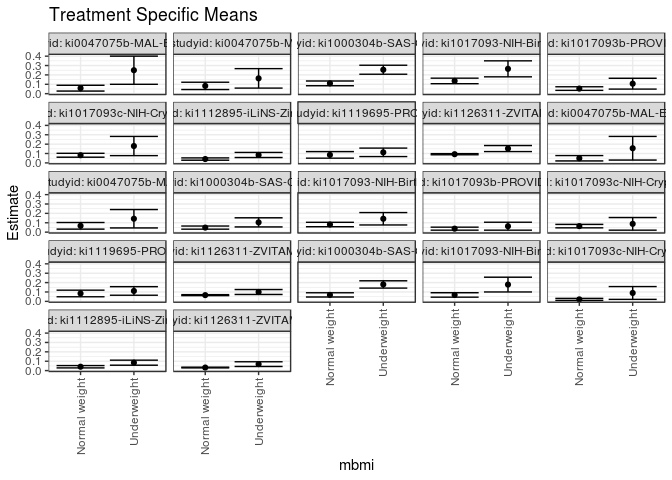

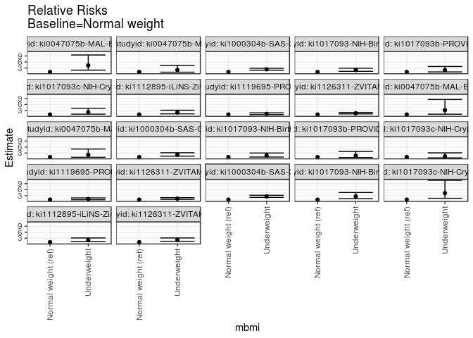

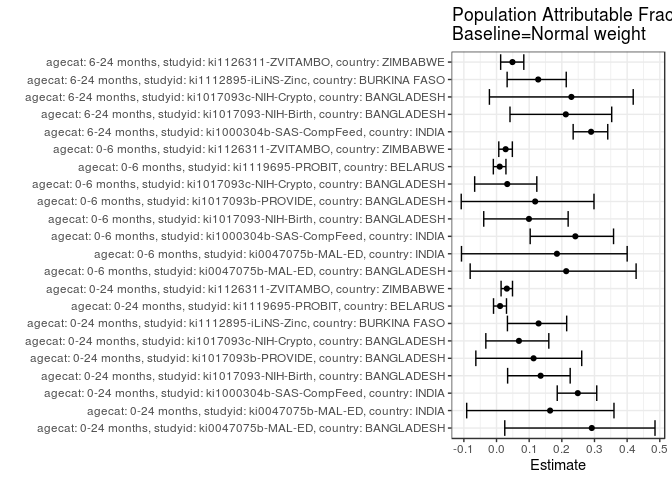

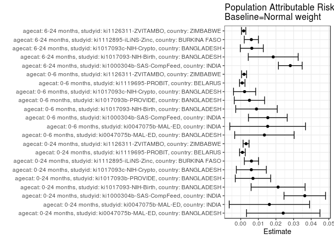

## Results Table

### Parameter: TSM

| agecat | studyid | country | intervention_level | baseline_level | estimate | ci_lower | ci_upper |
| --- | --- | --- | --- | --- | --- | --- | --- |
| 0-24 months | ki0047075b-MAL-ED | BANGLADESH | Normal weight | NA | 0.0585586 | 0.0276115 | 0.0895057 |
| 0-24 months | ki0047075b-MAL-ED | BANGLADESH | Underweight | NA | 0.2500000 | 0.0996753 | 0.4003247 |
| 0-24 months | ki0047075b-MAL-ED | INDIA | Normal weight | NA | 0.0829016 | 0.0439201 | 0.1218830 |
| 0-24 months | ki0047075b-MAL-ED | INDIA | Underweight | NA | 0.1632653 | 0.0595626 | 0.2669680 |
| 0-24 months | ki1000304b-SAS-CompFeed | INDIA | Normal weight | NA | 0.1097786 | 0.0845793 | 0.1349779 |
| 0-24 months | ki1000304b-SAS-CompFeed | INDIA | Underweight | NA | 0.2550914 | 0.2070099 | 0.3031730 |
| 0-24 months | ki1017093-NIH-Birth | BANGLADESH | Normal weight | NA | 0.1358362 | 0.1062917 | 0.1653808 |
| 0-24 months | ki1017093-NIH-Birth | BANGLADESH | Underweight | NA | 0.2648878 | 0.1796782 | 0.3500975 |
| 0-24 months | ki1017093b-PROVIDE | BANGLADESH | Normal weight | NA | 0.0543295 | 0.0352054 | 0.0734535 |
| 0-24 months | ki1017093b-PROVIDE | BANGLADESH | Underweight | NA | 0.1065143 | 0.0487850 | 0.1642437 |
| 0-24 months | ki1017093c-NIH-Crypto | BANGLADESH | Normal weight | NA | 0.0814134 | 0.0607146 | 0.1021121 |
| 0-24 months | ki1017093c-NIH-Crypto | BANGLADESH | Underweight | NA | 0.1799320 | 0.0776275 | 0.2822365 |
| 0-24 months | ki1112895-iLiNS-Zinc | BURKINA FASO | Normal weight | NA | 0.0411177 | 0.0287312 | 0.0535041 |
| 0-24 months | ki1112895-iLiNS-Zinc | BURKINA FASO | Underweight | NA | 0.0844259 | 0.0570942 | 0.1117576 |
| 0-24 months | ki1119695-PROBIT | BELARUS | Normal weight | NA | 0.0855243 | 0.0505019 | 0.1205466 |
| 0-24 months | ki1119695-PROBIT | BELARUS | Underweight | NA | 0.1125921 | 0.0673063 | 0.1578780 |
| 0-24 months | ki1126311-ZVITAMBO | ZIMBABWE | Normal weight | NA | 0.0928137 | 0.0869041 | 0.0987234 |
| 0-24 months | ki1126311-ZVITAMBO | ZIMBABWE | Underweight | NA | 0.1528804 | 0.1207078 | 0.1850530 |
| 0-6 months | ki0047075b-MAL-ED | BANGLADESH | Normal weight | NA | 0.0495495 | 0.0209465 | 0.0781526 |
| 0-6 months | ki0047075b-MAL-ED | BANGLADESH | Underweight | NA | 0.1562500 | 0.0301989 | 0.2823011 |
| 0-6 months | ki0047075b-MAL-ED | INDIA | Normal weight | NA | 0.0673575 | 0.0319236 | 0.1027914 |
| 0-6 months | ki0047075b-MAL-ED | INDIA | Underweight | NA | 0.1428571 | 0.0446763 | 0.2410380 |
| 0-6 months | ki1000304b-SAS-CompFeed | INDIA | Normal weight | NA | 0.0483042 | 0.0314791 | 0.0651292 |
| 0-6 months | ki1000304b-SAS-CompFeed | INDIA | Underweight | NA | 0.1041261 | 0.0553696 | 0.1528826 |
| 0-6 months | ki1017093-NIH-Birth | BANGLADESH | Normal weight | NA | 0.0810896 | 0.0575950 | 0.1045842 |
| 0-6 months | ki1017093-NIH-Birth | BANGLADESH | Underweight | NA | 0.1425338 | 0.0765594 | 0.2085082 |
| 0-6 months | ki1017093b-PROVIDE | BANGLADESH | Normal weight | NA | 0.0369004 | 0.0210177 | 0.0527831 |
| 0-6 months | ki1017093b-PROVIDE | BANGLADESH | Underweight | NA | 0.0629921 | 0.0207072 | 0.1052771 |
| 0-6 months | ki1017093c-NIH-Crypto | BANGLADESH | Normal weight | NA | 0.0640466 | 0.0457263 | 0.0823669 |
| 0-6 months | ki1017093c-NIH-Crypto | BANGLADESH | Underweight | NA | 0.0882353 | 0.0207757 | 0.1556949 |
| 0-6 months | ki1119695-PROBIT | BELARUS | Normal weight | NA | 0.0842515 | 0.0491403 | 0.1193627 |
| 0-6 months | ki1119695-PROBIT | BELARUS | Underweight | NA | 0.1111004 | 0.0654188 | 0.1567821 |
| 0-6 months | ki1126311-ZVITAMBO | ZIMBABWE | Normal weight | NA | 0.0663378 | 0.0612620 | 0.0714137 |
| 0-6 months | ki1126311-ZVITAMBO | ZIMBABWE | Underweight | NA | 0.0998192 | 0.0734072 | 0.1262311 |
| 6-24 months | ki1000304b-SAS-CompFeed | INDIA | Normal weight | NA | 0.0690339 | 0.0464067 | 0.0916610 |
| 6-24 months | ki1000304b-SAS-CompFeed | INDIA | Underweight | NA | 0.1803070 | 0.1414414 | 0.2191727 |
| 6-24 months | ki1017093-NIH-Birth | BANGLADESH | Normal weight | NA | 0.0684366 | 0.0449600 | 0.0919133 |
| 6-24 months | ki1017093-NIH-Birth | BANGLADESH | Underweight | NA | 0.1790187 | 0.1002966 | 0.2577407 |
| 6-24 months | ki1017093c-NIH-Crypto | BANGLADESH | Normal weight | NA | 0.0211161 | 0.0101649 | 0.0320673 |
| 6-24 months | ki1017093c-NIH-Crypto | BANGLADESH | Underweight | NA | 0.0895522 | 0.0211337 | 0.1579708 |
| 6-24 months | ki1112895-iLiNS-Zinc | BURKINA FASO | Normal weight | NA | 0.0411731 | 0.0287505 | 0.0535957 |
| 6-24 months | ki1112895-iLiNS-Zinc | BURKINA FASO | Underweight | NA | 0.0843722 | 0.0575681 | 0.1111764 |
| 6-24 months | ki1126311-ZVITAMBO | ZIMBABWE | Normal weight | NA | 0.0324525 | 0.0285913 | 0.0363136 |
| 6-24 months | ki1126311-ZVITAMBO | ZIMBABWE | Underweight | NA | 0.0690665 | 0.0440358 | 0.0940972 |

### Parameter: E(Y)

| agecat | studyid | country | intervention_level | baseline_level | estimate | ci_lower | ci_upper |
| --- | --- | --- | --- | --- | --- | --- | --- |
| 0-24 months | ki0047075b-MAL-ED | BANGLADESH | NA | NA | 0.0826772 | 0.0487426 | 0.1166117 |
| 0-24 months | ki0047075b-MAL-ED | INDIA | NA | NA | 0.0991736 | 0.0614374 | 0.1369097 |
| 0-24 months | ki1000304b-SAS-CompFeed | INDIA | NA | NA | 0.1461483 | 0.1147335 | 0.1775631 |
| 0-24 months | ki1017093-NIH-Birth | BANGLADESH | NA | NA | 0.1570513 | 0.1284803 | 0.1856223 |
| 0-24 months | ki1017093b-PROVIDE | BANGLADESH | NA | NA | 0.0612855 | 0.0430966 | 0.0794744 |
| 0-24 months | ki1017093c-NIH-Crypto | BANGLADESH | NA | NA | 0.0874172 | 0.0672569 | 0.1075775 |
| 0-24 months | ki1112895-iLiNS-Zinc | BURKINA FASO | NA | NA | 0.0471995 | 0.0353423 | 0.0590566 |
| 0-24 months | ki1119695-PROBIT | BELARUS | NA | NA | 0.0864656 | 0.0516689 | 0.1212624 |
| 0-24 months | ki1126311-ZVITAMBO | ZIMBABWE | NA | NA | 0.0958457 | 0.0900162 | 0.1016752 |
| 0-6 months | ki0047075b-MAL-ED | BANGLADESH | NA | NA | 0.0629921 | 0.0330555 | 0.0929287 |
| 0-6 months | ki0047075b-MAL-ED | INDIA | NA | NA | 0.0826446 | 0.0478818 | 0.1174075 |
| 0-6 months | ki1000304b-SAS-CompFeed | INDIA | NA | NA | 0.0636758 | 0.0409275 | 0.0864242 |
| 0-6 months | ki1017093-NIH-Birth | BANGLADESH | NA | NA | 0.0900322 | 0.0675202 | 0.1125442 |
| 0-6 months | ki1017093b-PROVIDE | BANGLADESH | NA | NA | 0.0418535 | 0.0266676 | 0.0570395 |
| 0-6 months | ki1017093c-NIH-Crypto | BANGLADESH | NA | NA | 0.0662252 | 0.0484753 | 0.0839750 |
| 0-6 months | ki1119695-PROBIT | BELARUS | NA | NA | 0.0850816 | 0.0501716 | 0.1199915 |
| 0-6 months | ki1126311-ZVITAMBO | ZIMBABWE | NA | NA | 0.0682447 | 0.0632414 | 0.0732480 |
| 6-24 months | ki1000304b-SAS-CompFeed | INDIA | NA | NA | 0.0971787 | 0.0698067 | 0.1245507 |
| 6-24 months | ki1017093-NIH-Birth | BANGLADESH | NA | NA | 0.0868762 | 0.0631205 | 0.1106318 |
| 6-24 months | ki1017093c-NIH-Crypto | BANGLADESH | NA | NA | 0.0273973 | 0.0155476 | 0.0392469 |
| 6-24 months | ki1112895-iLiNS-Zinc | BURKINA FASO | NA | NA | 0.0471995 | 0.0353423 | 0.0590566 |
| 6-24 months | ki1126311-ZVITAMBO | ZIMBABWE | NA | NA | 0.0341161 | 0.0302702 | 0.0379621 |

### Parameter: RR

| agecat | studyid | country | intervention_level | baseline_level | estimate | ci_lower | ci_upper |
| --- | --- | --- | --- | --- | --- | --- | --- |
| 0-24 months | ki0047075b-MAL-ED | BANGLADESH | Normal weight | Normal weight | 1.000000 | 1.0000000 | 1.000000 |
| 0-24 months | ki0047075b-MAL-ED | BANGLADESH | Underweight | Normal weight | 4.269231 | 1.9172672 | 9.506412 |
| 0-24 months | ki0047075b-MAL-ED | INDIA | Normal weight | Normal weight | 1.000000 | 1.0000000 | 1.000000 |
| 0-24 months | ki0047075b-MAL-ED | INDIA | Underweight | Normal weight | 1.969388 | 0.8935400 | 4.340587 |
| 0-24 months | ki1000304b-SAS-CompFeed | INDIA | Normal weight | Normal weight | 1.000000 | 1.0000000 | 1.000000 |
| 0-24 months | ki1000304b-SAS-CompFeed | INDIA | Underweight | Normal weight | 2.323689 | 1.8968563 | 2.846568 |
| 0-24 months | ki1017093-NIH-Birth | BANGLADESH | Normal weight | Normal weight | 1.000000 | 1.0000000 | 1.000000 |
| 0-24 months | ki1017093-NIH-Birth | BANGLADESH | Underweight | Normal weight | 1.950052 | 1.3223796 | 2.875653 |
| 0-24 months | ki1017093b-PROVIDE | BANGLADESH | Normal weight | Normal weight | 1.000000 | 1.0000000 | 1.000000 |
| 0-24 months | ki1017093b-PROVIDE | BANGLADESH | Underweight | Normal weight | 1.960526 | 1.0272631 | 3.741655 |
| 0-24 months | ki1017093c-NIH-Crypto | BANGLADESH | Normal weight | Normal weight | 1.000000 | 1.0000000 | 1.000000 |
| 0-24 months | ki1017093c-NIH-Crypto | BANGLADESH | Underweight | Normal weight | 2.210104 | 1.1841949 | 4.124794 |
| 0-24 months | ki1112895-iLiNS-Zinc | BURKINA FASO | Normal weight | Normal weight | 1.000000 | 1.0000000 | 1.000000 |
| 0-24 months | ki1112895-iLiNS-Zinc | BURKINA FASO | Underweight | Normal weight | 2.053277 | 1.3374717 | 3.152176 |
| 0-24 months | ki1119695-PROBIT | BELARUS | Normal weight | Normal weight | 1.000000 | 1.0000000 | 1.000000 |
| 0-24 months | ki1119695-PROBIT | BELARUS | Underweight | Normal weight | 1.316493 | 0.9385496 | 1.846630 |
| 0-24 months | ki1126311-ZVITAMBO | ZIMBABWE | Normal weight | Normal weight | 1.000000 | 1.0000000 | 1.000000 |
| 0-24 months | ki1126311-ZVITAMBO | ZIMBABWE | Underweight | Normal weight | 1.647174 | 1.3220605 | 2.052239 |
| 0-6 months | ki0047075b-MAL-ED | BANGLADESH | Normal weight | Normal weight | 1.000000 | 1.0000000 | 1.000000 |
| 0-6 months | ki0047075b-MAL-ED | BANGLADESH | Underweight | Normal weight | 3.153409 | 1.1694063 | 8.503450 |
| 0-6 months | ki0047075b-MAL-ED | INDIA | Normal weight | Normal weight | 1.000000 | 1.0000000 | 1.000000 |
| 0-6 months | ki0047075b-MAL-ED | INDIA | Underweight | Normal weight | 2.120879 | 0.8925630 | 5.039564 |
| 0-6 months | ki1000304b-SAS-CompFeed | INDIA | Normal weight | Normal weight | 1.000000 | 1.0000000 | 1.000000 |
| 0-6 months | ki1000304b-SAS-CompFeed | INDIA | Underweight | Normal weight | 2.155633 | 1.4612626 | 3.179958 |
| 0-6 months | ki1017093-NIH-Birth | BANGLADESH | Normal weight | Normal weight | 1.000000 | 1.0000000 | 1.000000 |
| 0-6 months | ki1017093-NIH-Birth | BANGLADESH | Underweight | Normal weight | 1.757732 | 1.0177360 | 3.035779 |
| 0-6 months | ki1017093b-PROVIDE | BANGLADESH | Normal weight | Normal weight | 1.000000 | 1.0000000 | 1.000000 |
| 0-6 months | ki1017093b-PROVIDE | BANGLADESH | Underweight | Normal weight | 1.707087 | 0.7690289 | 3.789382 |
| 0-6 months | ki1017093c-NIH-Crypto | BANGLADESH | Normal weight | Normal weight | 1.000000 | 1.0000000 | 1.000000 |
| 0-6 months | ki1017093c-NIH-Crypto | BANGLADESH | Underweight | Normal weight | 1.377674 | 0.6090195 | 3.116460 |
| 0-6 months | ki1119695-PROBIT | BELARUS | Normal weight | Normal weight | 1.000000 | 1.0000000 | 1.000000 |
| 0-6 months | ki1119695-PROBIT | BELARUS | Underweight | Normal weight | 1.318676 | 0.9359338 | 1.857937 |
| 0-6 months | ki1126311-ZVITAMBO | ZIMBABWE | Normal weight | Normal weight | 1.000000 | 1.0000000 | 1.000000 |
| 0-6 months | ki1126311-ZVITAMBO | ZIMBABWE | Underweight | Normal weight | 1.504709 | 1.1423911 | 1.981939 |
| 6-24 months | ki1000304b-SAS-CompFeed | INDIA | Normal weight | Normal weight | 1.000000 | 1.0000000 | 1.000000 |
| 6-24 months | ki1000304b-SAS-CompFeed | INDIA | Underweight | Normal weight | 2.611864 | 2.1260644 | 3.208666 |
| 6-24 months | ki1017093-NIH-Birth | BANGLADESH | Normal weight | Normal weight | 1.000000 | 1.0000000 | 1.000000 |
| 6-24 months | ki1017093-NIH-Birth | BANGLADESH | Underweight | Normal weight | 2.615831 | 1.4982386 | 4.567077 |
| 6-24 months | ki1017093c-NIH-Crypto | BANGLADESH | Normal weight | Normal weight | 1.000000 | 1.0000000 | 1.000000 |
| 6-24 months | ki1017093c-NIH-Crypto | BANGLADESH | Underweight | Normal weight | 4.240938 | 1.6843541 | 10.678014 |
| 6-24 months | ki1112895-iLiNS-Zinc | BURKINA FASO | Normal weight | Normal weight | 1.000000 | 1.0000000 | 1.000000 |
| 6-24 months | ki1112895-iLiNS-Zinc | BURKINA FASO | Underweight | Normal weight | 2.049209 | 1.3432794 | 3.126123 |
| 6-24 months | ki1126311-ZVITAMBO | ZIMBABWE | Normal weight | Normal weight | 1.000000 | 1.0000000 | 1.000000 |
| 6-24 months | ki1126311-ZVITAMBO | ZIMBABWE | Underweight | Normal weight | 2.128235 | 1.4533265 | 3.116564 |

### Parameter: PAR

| agecat | studyid | country | intervention_level | baseline_level | estimate | ci_lower | ci_upper |
| --- | --- | --- | --- | --- | --- | --- | --- |
| 0-24 months | ki0047075b-MAL-ED | BANGLADESH | Normal weight | NA | 0.0241186 | 0.0032585 | 0.0449787 |
| 0-24 months | ki0047075b-MAL-ED | INDIA | Normal weight | NA | 0.0162720 | -0.0065276 | 0.0390716 |
| 0-24 months | ki1000304b-SAS-CompFeed | INDIA | Normal weight | NA | 0.0363697 | 0.0245781 | 0.0481613 |
| 0-24 months | ki1017093-NIH-Birth | BANGLADESH | Normal weight | NA | 0.0212150 | 0.0058995 | 0.0365306 |
| 0-24 months | ki1017093b-PROVIDE | BANGLADESH | Normal weight | NA | 0.0069560 | -0.0030870 | 0.0169991 |
| 0-24 months | ki1017093c-NIH-Crypto | BANGLADESH | Normal weight | NA | 0.0060038 | -0.0025021 | 0.0145098 |
| 0-24 months | ki1112895-iLiNS-Zinc | BURKINA FASO | Normal weight | NA | 0.0060818 | 0.0020330 | 0.0101307 |
| 0-24 months | ki1119695-PROBIT | BELARUS | Normal weight | NA | 0.0009413 | -0.0006903 | 0.0025730 |
| 0-24 months | ki1126311-ZVITAMBO | ZIMBABWE | Normal weight | NA | 0.0030319 | 0.0013482 | 0.0047157 |
| 0-6 months | ki0047075b-MAL-ED | BANGLADESH | Normal weight | NA | 0.0134426 | -0.0034159 | 0.0303011 |
| 0-6 months | ki0047075b-MAL-ED | INDIA | Normal weight | NA | 0.0152871 | -0.0061918 | 0.0367661 |
| 0-6 months | ki1000304b-SAS-CompFeed | INDIA | Normal weight | NA | 0.0153717 | 0.0043664 | 0.0263769 |
| 0-6 months | ki1017093-NIH-Birth | BANGLADESH | Normal weight | NA | 0.0089425 | -0.0028381 | 0.0207231 |
| 0-6 months | ki1017093b-PROVIDE | BANGLADESH | Normal weight | NA | 0.0049531 | -0.0036567 | 0.0135629 |
| 0-6 months | ki1017093c-NIH-Crypto | BANGLADESH | Normal weight | NA | 0.0021786 | -0.0041367 | 0.0084939 |
| 0-6 months | ki1119695-PROBIT | BELARUS | Normal weight | NA | 0.0008301 | -0.0007404 | 0.0024006 |
| 0-6 months | ki1126311-ZVITAMBO | ZIMBABWE | Normal weight | NA | 0.0019069 | 0.0004835 | 0.0033302 |
| 6-24 months | ki1000304b-SAS-CompFeed | INDIA | Normal weight | NA | 0.0281448 | 0.0214013 | 0.0348883 |
| 6-24 months | ki1017093-NIH-Birth | BANGLADESH | Normal weight | NA | 0.0184395 | 0.0042732 | 0.0326058 |
| 6-24 months | ki1017093c-NIH-Crypto | BANGLADESH | Normal weight | NA | 0.0062811 | -0.0002381 | 0.0128003 |
| 6-24 months | ki1112895-iLiNS-Zinc | BURKINA FASO | Normal weight | NA | 0.0060264 | 0.0020006 | 0.0100522 |
| 6-24 months | ki1126311-ZVITAMBO | ZIMBABWE | Normal weight | NA | 0.0016637 | 0.0004417 | 0.0028856 |

### Parameter: PAF

| agecat | studyid | country | intervention_level | baseline_level | estimate | ci_lower | ci_upper |
| --- | --- | --- | --- | --- | --- | --- | --- |
| 0-24 months | ki0047075b-MAL-ED | BANGLADESH | Normal weight | NA | 0.2917203 | 0.0252675 | 0.4853356 |
| 0-24 months | ki0047075b-MAL-ED | INDIA | Normal weight | NA | 0.1640760 | -0.0913332 | 0.3597107 |
| 0-24 months | ki1000304b-SAS-CompFeed | INDIA | Normal weight | NA | 0.2488546 | 0.1859316 | 0.3069139 |
| 0-24 months | ki1017093-NIH-Birth | BANGLADESH | Normal weight | NA | 0.1350835 | 0.0340010 | 0.2255887 |
| 0-24 months | ki1017093b-PROVIDE | BANGLADESH | Normal weight | NA | 0.1135023 | -0.0633224 | 0.2609220 |
| 0-24 months | ki1017093c-NIH-Crypto | BANGLADESH | Normal weight | NA | 0.0686804 | -0.0327311 | 0.1601336 |
| 0-24 months | ki1112895-iLiNS-Zinc | BURKINA FASO | Normal weight | NA | 0.1288539 | 0.0334243 | 0.2148618 |
| 0-24 months | ki1119695-PROBIT | BELARUS | Normal weight | NA | 0.0108869 | -0.0091717 | 0.0305469 |
| 0-24 months | ki1126311-ZVITAMBO | ZIMBABWE | Normal weight | NA | 0.0316336 | 0.0139880 | 0.0489633 |
| 0-6 months | ki0047075b-MAL-ED | BANGLADESH | Normal weight | NA | 0.2134009 | -0.0806932 | 0.4274618 |
| 0-6 months | ki0047075b-MAL-ED | INDIA | Normal weight | NA | 0.1849741 | -0.1072848 | 0.4000936 |
| 0-6 months | ki1000304b-SAS-CompFeed | INDIA | Normal weight | NA | 0.2414048 | 0.1030965 | 0.3583851 |
| 0-6 months | ki1017093-NIH-Birth | BANGLADESH | Normal weight | NA | 0.0993259 | -0.0391483 | 0.2193475 |
| 0-6 months | ki1017093b-PROVIDE | BANGLADESH | Normal weight | NA | 0.1183448 | -0.1080833 | 0.2985040 |
| 0-6 months | ki1017093c-NIH-Crypto | BANGLADESH | Normal weight | NA | 0.0328967 | -0.0669351 | 0.1233873 |
| 0-6 months | ki1119695-PROBIT | BELARUS | Normal weight | NA | 0.0097563 | -0.0097312 | 0.0288677 |
| 0-6 months | ki1126311-ZVITAMBO | ZIMBABWE | Normal weight | NA | 0.0279415 | 0.0069470 | 0.0484921 |
| 6-24 months | ki1000304b-SAS-CompFeed | INDIA | Normal weight | NA | 0.2896192 | 0.2346857 | 0.3406096 |
| 6-24 months | ki1017093-NIH-Birth | BANGLADESH | Normal weight | NA | 0.2122506 | 0.0412688 | 0.3527391 |
| 6-24 months | ki1017093c-NIH-Crypto | BANGLADESH | Normal weight | NA | 0.2292609 | -0.0217519 | 0.4186077 |
| 6-24 months | ki1112895-iLiNS-Zinc | BURKINA FASO | Normal weight | NA | 0.1276797 | 0.0324941 | 0.2135007 |
| 6-24 months | ki1126311-ZVITAMBO | ZIMBABWE | Normal weight | NA | 0.0487647 | 0.0126634 | 0.0835461 |